# TiDEomics Application: Macrophage response to six immune stimuli

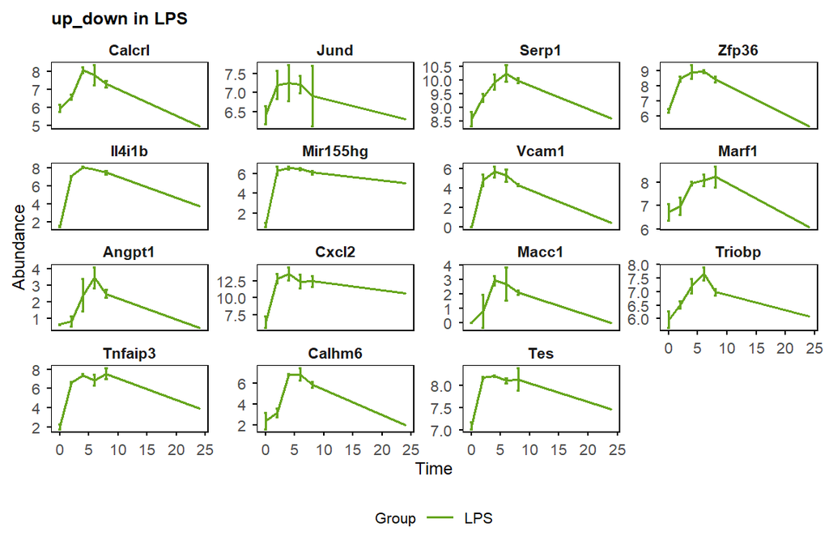

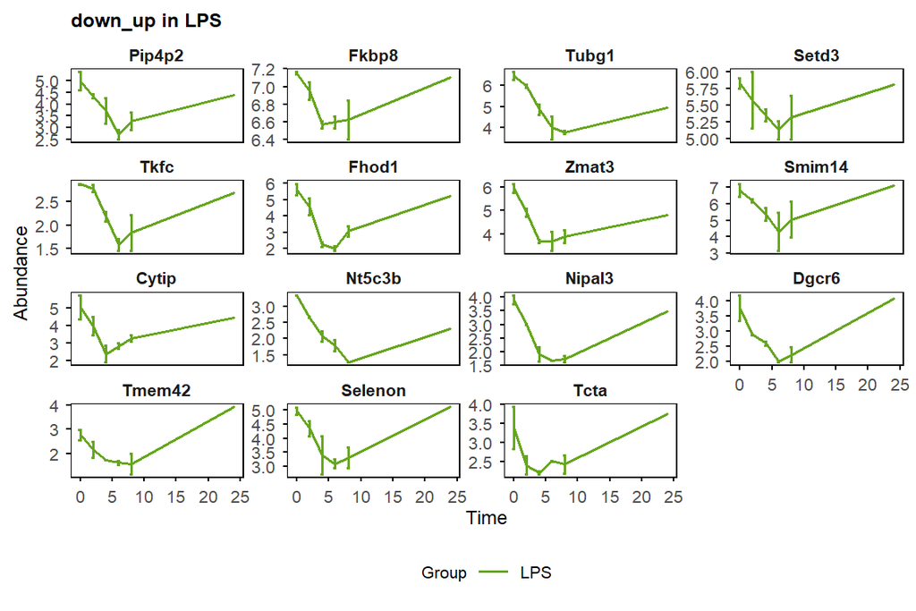

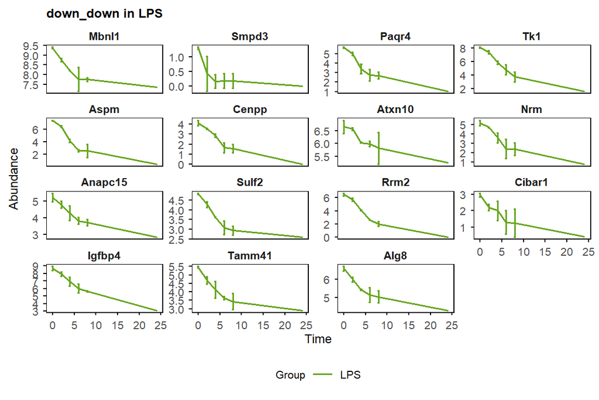

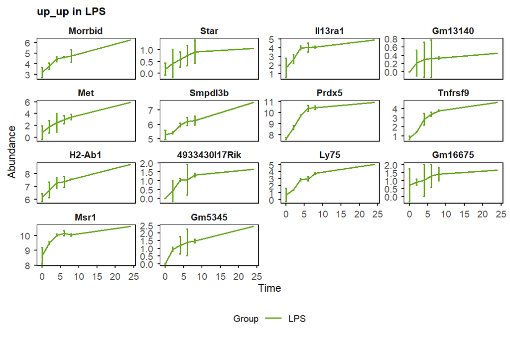

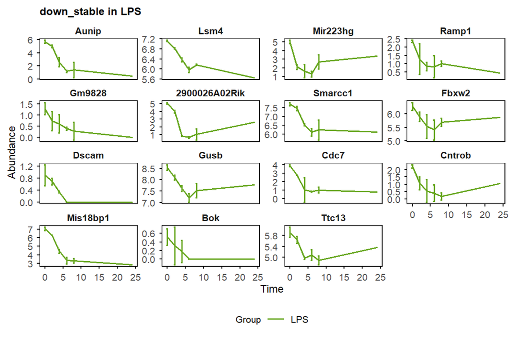

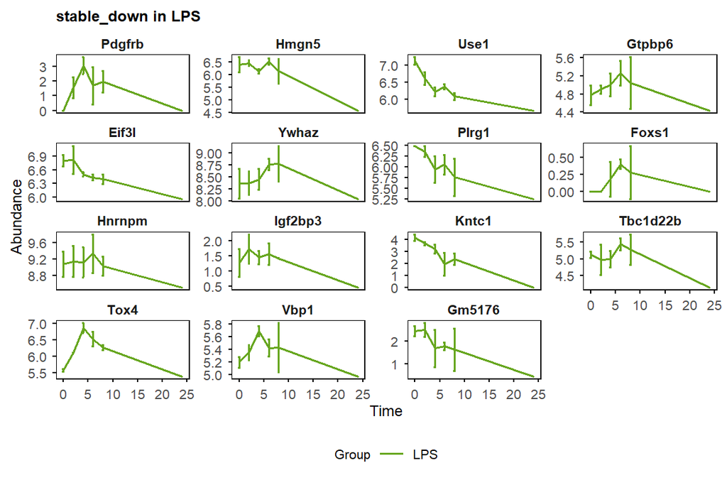

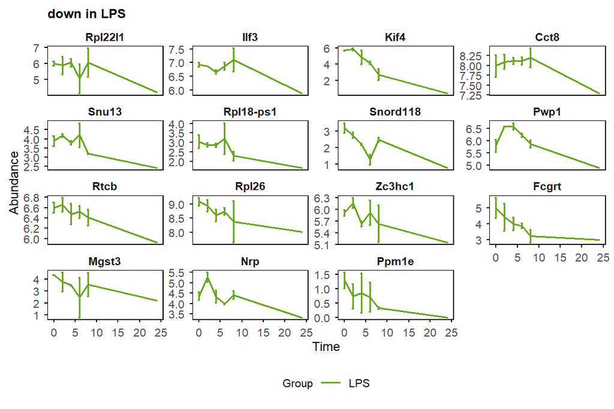

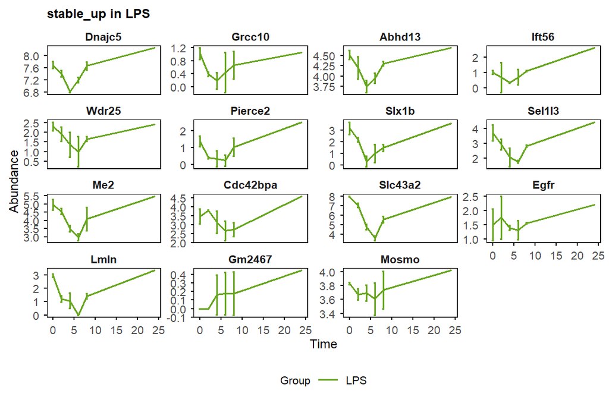

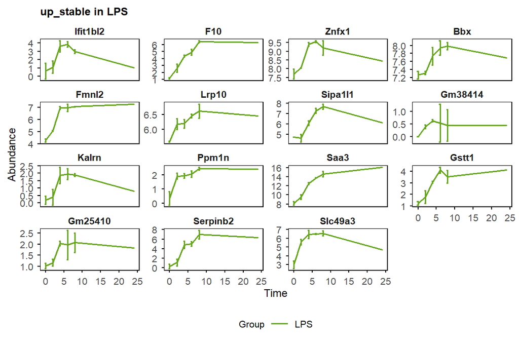

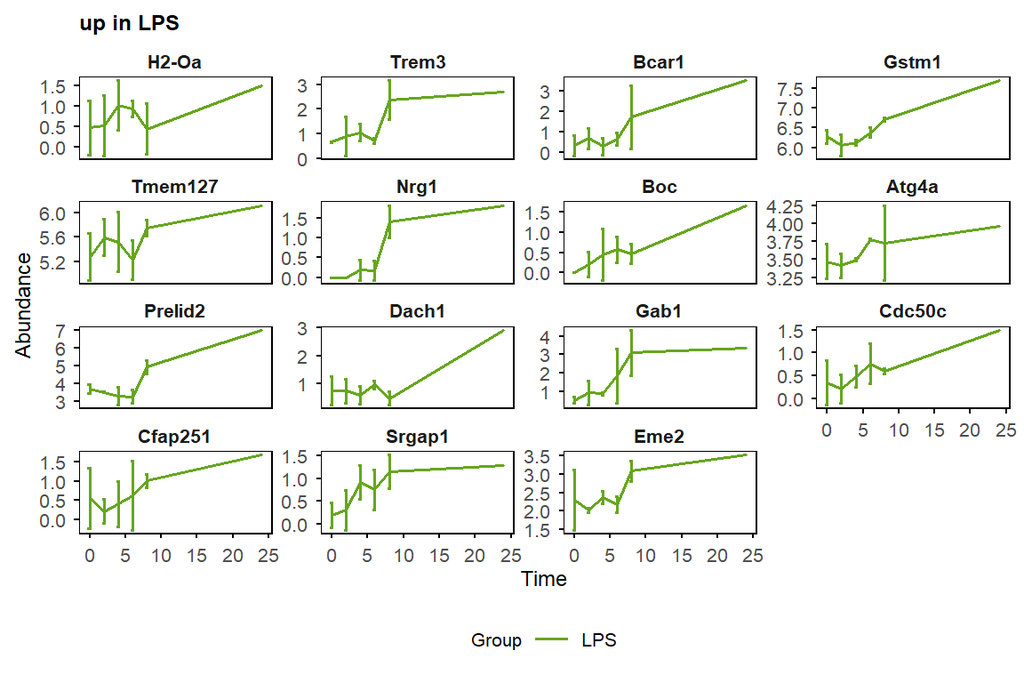

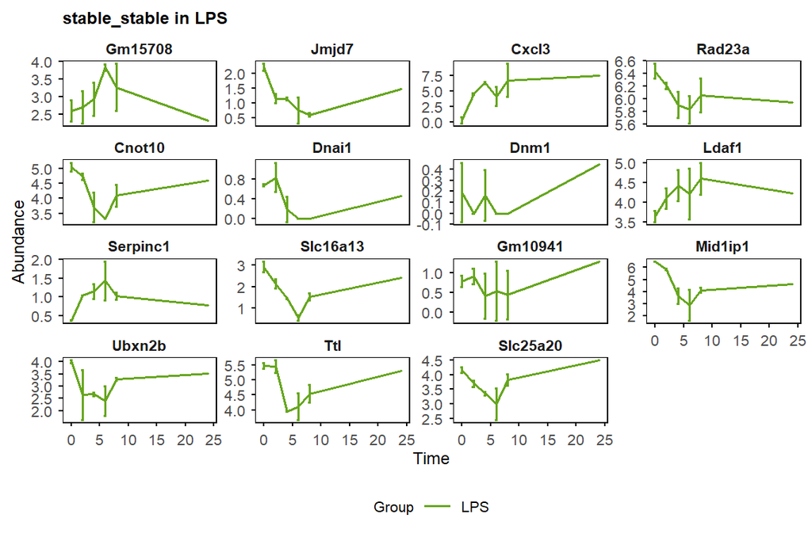

```r
# plot example genes with different trend patterns
i <- "LPS"
for (j in names(trendy_list[[i]])) {
    if (!is.null(trendy_list[[i]][[j]])) {
        print(plot_trend(table_mean_sd_orig,
            groups = i,
            features = trendy_list[[i]][[j]] %>%
                sample(min(15, length(trendy_list[[i]][[j]]))),
            title = paste0(j)
        ))
    }
}
```

# 11 Variance decomposition analysis

## 11.1 Filter input

Input features are filtered to have at least 50% values > 0 in at least 2 groups, as comparison between groups is needed.

```r
filter_ratio <- 0.5
decomp_filter_genes <- group_specific_features(property_random_fc,
    filter_ratio = filter_ratio,
    group_pct = 2 / length(unique(data_obj$Group)),
    GO = FALSE, genename = FALSE
)$features
```

```
#> Filtering criteria: >=50% values >0 in >=2 of groups: Candida, IFNbeta, IFNgamma, LCMV, Listeria, LPS, untreated
```

## 11.2 Original data (not time 0 normalised) with replicates

Compared to normalised data, only using original data can identify genes with stable but different levels of expression in groups.

```r
var_decomp_1 <- decomp_variance(data_obj,
    features = decomp_filter_genes,
    interaction = TRUE,
    assay = 1, core = 16
)
```

```
#> Max 2 replicate(s): interaction variance estimate may be unstable.
#> LMM: exp ~ (1|Group) + (1|Time) + (1|Group:Time)  |  Output: Group, Time, Group:Time, Residual
```

```
#> Features not specified. Plotting top 20 features ranked by Time.
```

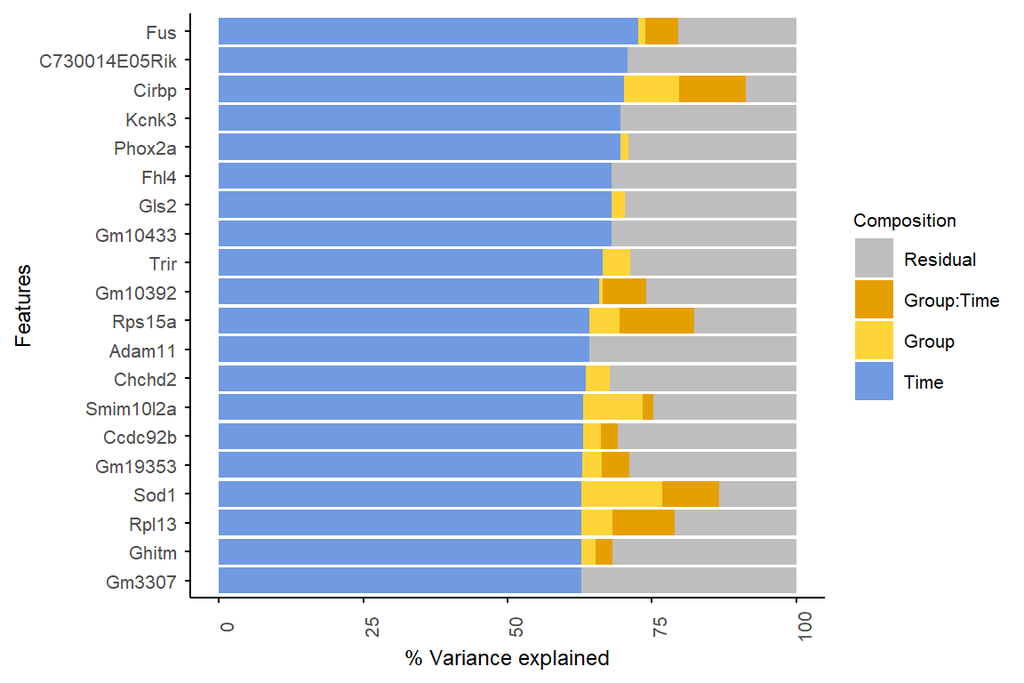

```r
plot_variance(var_decomp_1, rank = "Time", top_n = 20)
```

```
#> Features not specified. Plotting top 20 features ranked by Group.
```

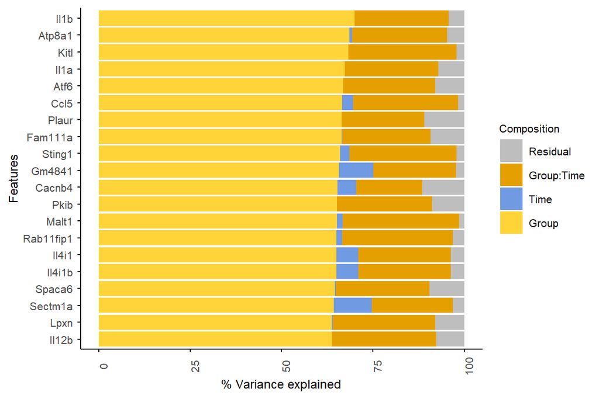

```r
plot_variance(var_decomp_1, rank = "Group", top_n = 20)
```

```
#> Group not specified. Plotting all groups: Candida, IFNbeta, IFNgamma, LCMV, Listeria, LPS, untreated
```

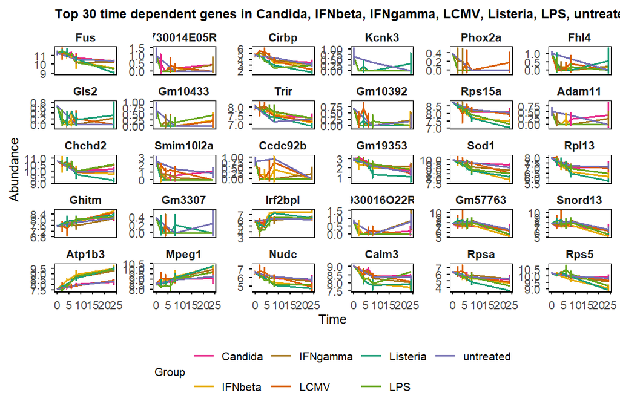

```r
plot_trend(table_mean_sd_orig,
    features = var_decomp_1 %>% arrange(desc(Time)) %>% head(30) %>% pull(Feature),
    title = "Top 30 time dependent genes"
)
```

```
#> Group not specified. Plotting all groups: Candida, IFNbeta, IFNgamma, LCMV, Listeria, LPS, untreated
```

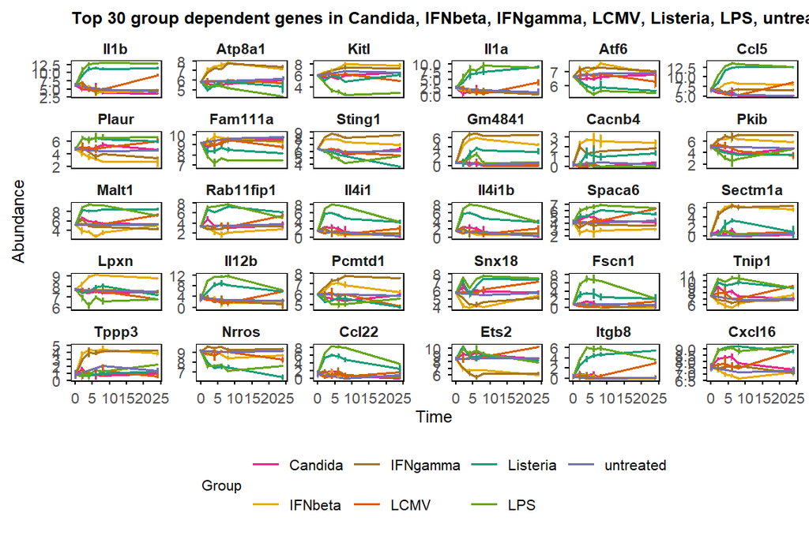

```r
plot_trend(table_mean_sd_orig,
    features = var_decomp_1 %>% arrange(desc(Group)) %>% head(30) %>% pull(Feature),
    title = "Top 30 group dependent genes"
)
```

### 11.2.1 Residual variance quantified data quality

```
#> Group not specified. Plotting all groups: Candida, IFNbeta, IFNgamma, LCMV, Listeria, LPS, untreated
```

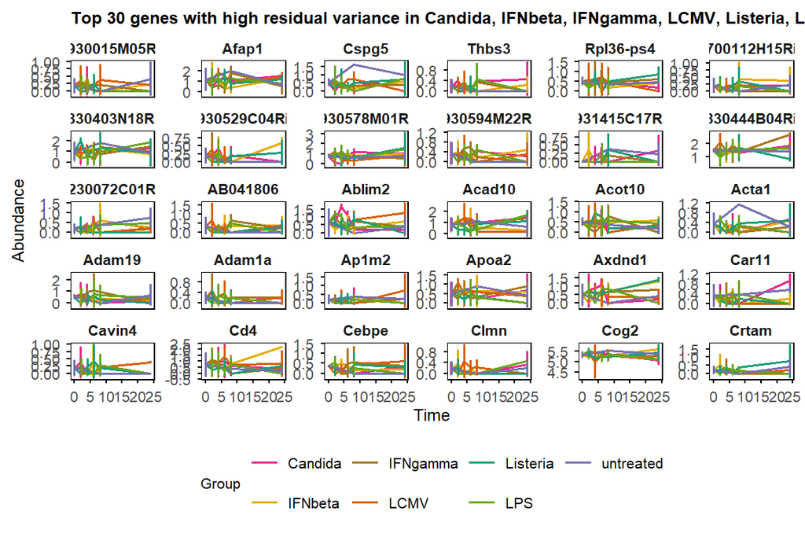

```r
plot_trend(table_mean_sd_orig,
    features = var_decomp_1 %>% arrange(desc(Residual)) %>% head(30) %>% pull(Feature),
    title = "Top 30 genes with high residual variance"
)
```

```
#> Group not specified. Plotting all groups: Candida, IFNbeta, IFNgamma, LCMV, Listeria, LPS, untreated
```

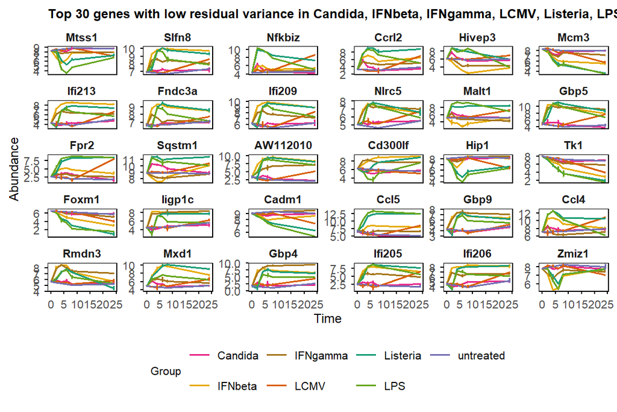

```r
plot_trend(table_mean_sd_orig,
    features = var_decomp_1 %>% arrange(Residual) %>% head(30) %>% pull(Feature),
    title = "Top 30 genes with low residual variance"
)
```

```
#> Group not specified. Plotting all groups: Candida, IFNbeta, IFNgamma, LCMV, Listeria, LPS, untreated
```

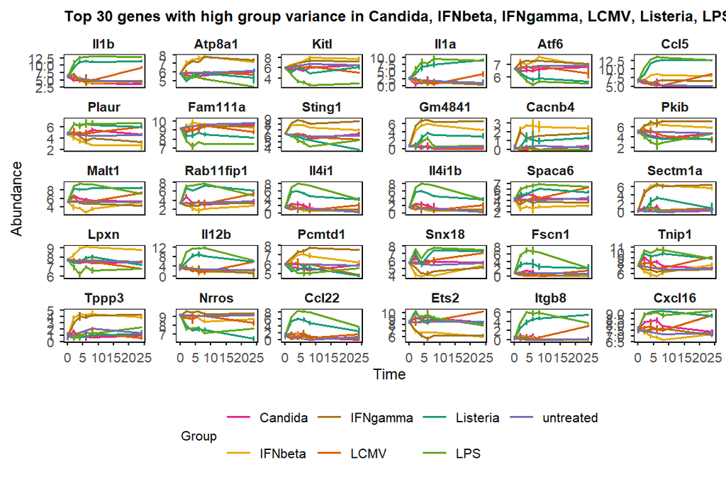

```r
plot_trend(table_mean_sd_orig,
    features = var_decomp_1 %>% arrange(desc(Group)) %>% head(30) %>% pull(Feature),
    title = "Top 30 genes with high group variance"
)
```

```
#> Group not specified. Plotting all groups: Candida, IFNbeta, IFNgamma, LCMV, Listeria, LPS, untreated
```

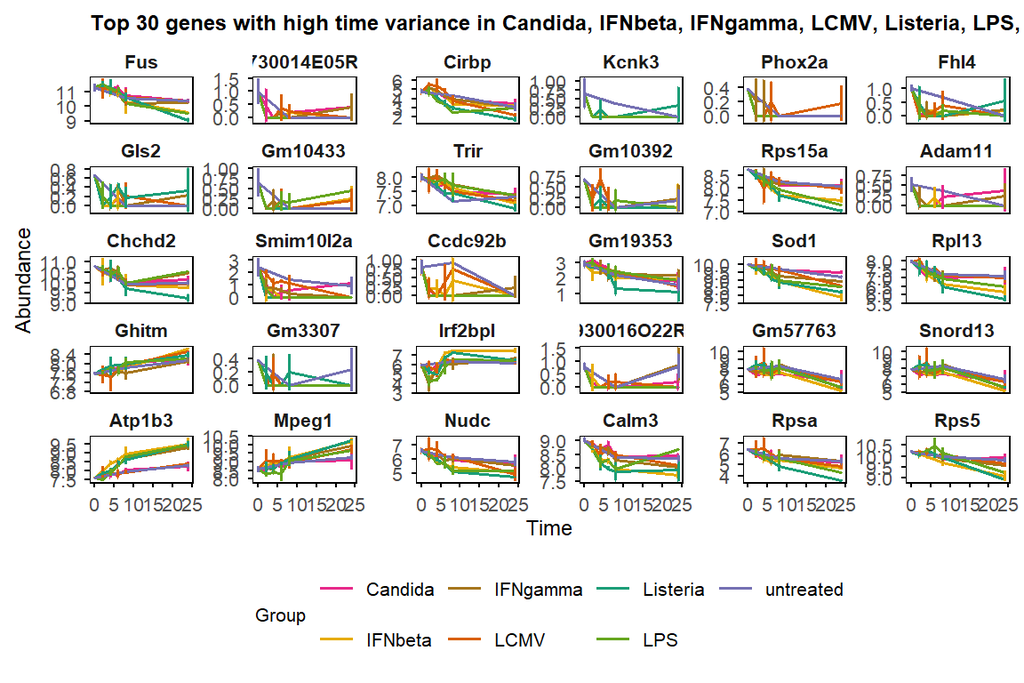

```r
plot_trend(table_mean_sd_orig,
    features = var_decomp_1 %>% arrange(desc(Time)) %>% head(30) %>% pull(Feature),
    title = "Top 30 genes with high time variance"
)
```

```
#> Group not specified. Plotting all groups: Candida, IFNbeta, IFNgamma, LCMV, Listeria, LPS, untreated
```

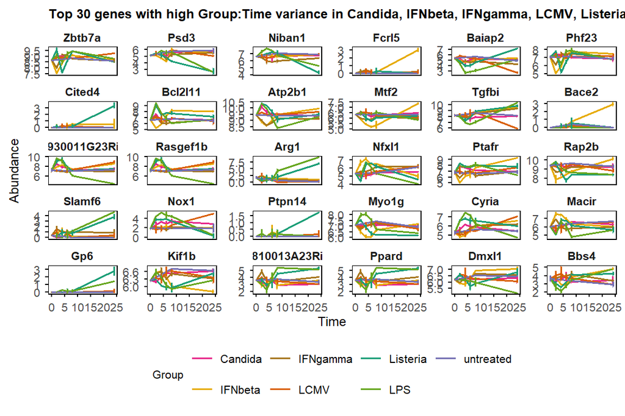

```r
plot_trend(table_mean_sd_orig,
    features = var_decomp_1 %>% arrange(desc(`Group:Time`)) %>% head(30) %>% pull(Feature),
    title = "Top 30 genes with high Group:Time variance"
)
```

### 11.2.2 GO enrichment of genes ranked by group/time-contributed variance

`enrichGO_rank()` returns a named list indexed by GO category (e.g. `$BP`, `$MF`, `$CC`). Access results with `$BP` before passing to `enrichplot::gseaplot2()`.

```r
gse_group <- enrichGO_rank(var_decomp_1,
    gene_rank_by = "Group",
    OrgDb = org.Mm.eg.db,
    keyType = "SYMBOL", category = "BP",
    go_rank_by = "p.adjust")
```

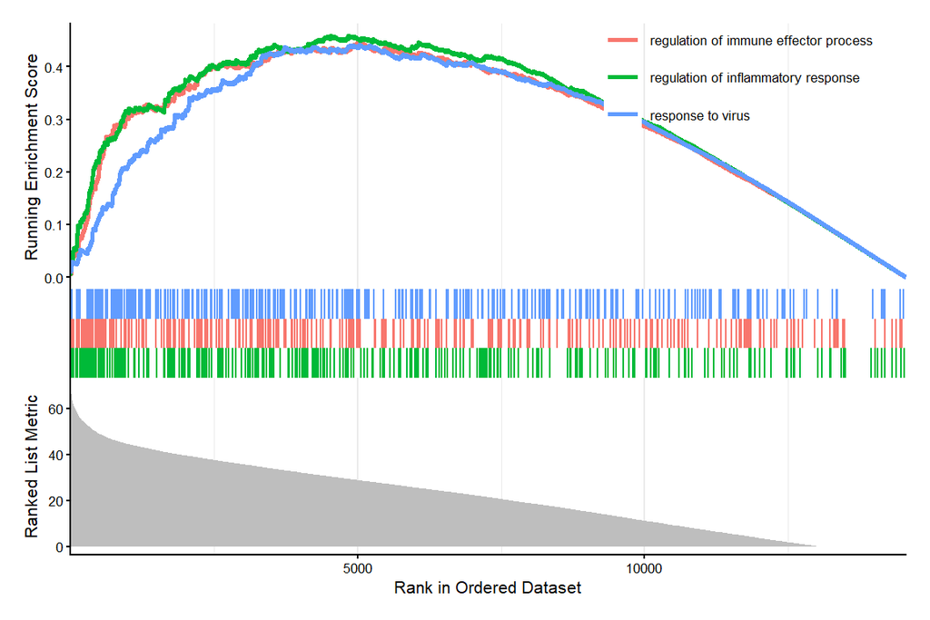

```r
enrichplot::gseaplot2(gse_group[["BP"]], geneSetID = 1:3, base_size = 8)
```

```r
gse_time <- enrichGO_rank(var_decomp_1,
    gene_rank_by = "Time",
    OrgDb = org.Mm.eg.db,
    keyType = "SYMBOL", category = "BP",
    go_rank_by = "p.adjust")
```

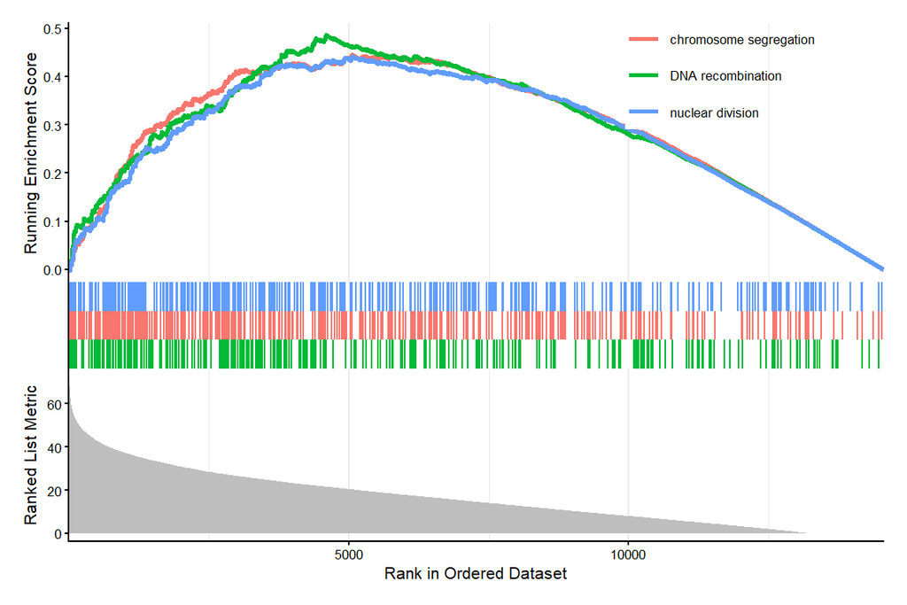

```r
enrichplot::gseaplot2(gse_time[["BP"]], geneSetID = 1:3, base_size = 8)
```

```r
gse_grouptime <- enrichGO_rank(var_decomp_1,
    gene_rank_by = "Group:Time",
    OrgDb = org.Mm.eg.db,
    keyType = "SYMBOL", category = "BP",
    go_rank_by = "p.adjust")
```

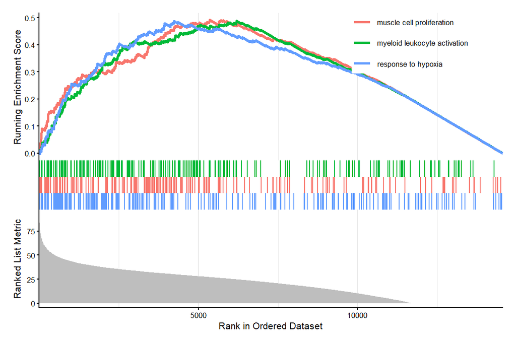

```r
enrichplot::gseaplot2(gse_grouptime[["BP"]], geneSetID = 1:3, base_size = 8)
```

## 11.3 Time 0 normalised data with replicates

Time 0 normalised data will be used as WGCNA input, so variance decomposition is also performed on time 0 normalised data to filter for WGCNA input

```r
var_decomp_2 <- decomp_variance(data_obj,
    features = decomp_filter_genes,
    interaction = TRUE,
    assay = 2, core = 16
)
```

```
#> Max 2 replicate(s): interaction variance estimate may be unstable.
#> LMM: exp ~ (1|Group) + (1|Time) + (1|Group:Time)  |  Output: Group, Time, Group:Time, Residual
```

```
#> Features not specified. Plotting top 20 features ranked by Time.
```

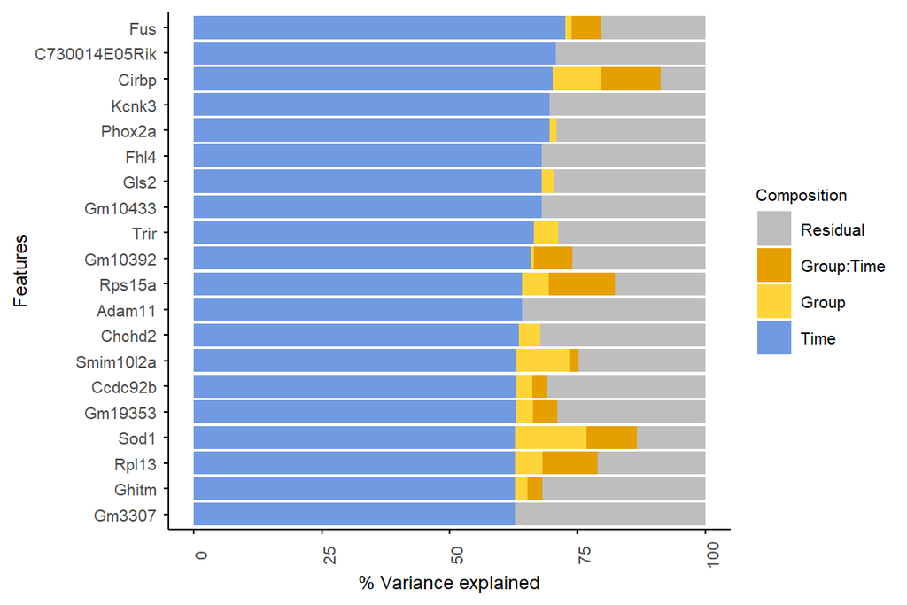

```r
plot_variance(var_decomp_2, rank = "Time", top_n = 20)
```

```
#> Features not specified. Plotting top 20 features ranked by Group.
```

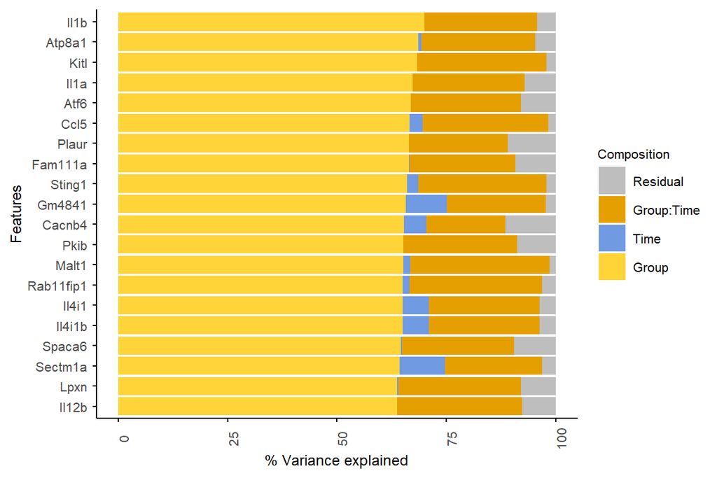

```r
plot_variance(var_decomp_2, rank = "Group", top_n = 20)
```

### 11.3.1 Residual variance quantified data quality

```
#> Group not specified. Plotting all groups: Candida, IFNbeta, IFNgamma, LCMV, Listeria, LPS, untreated
```

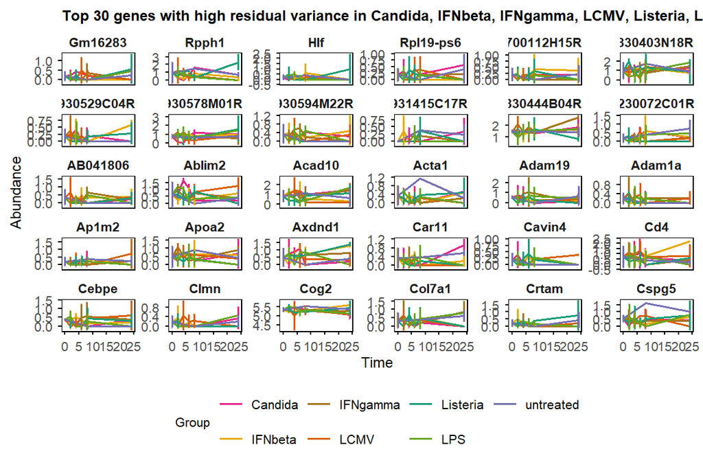

```r
plot_trend(table_mean_sd_orig,
    features = var_decomp_2 %>% arrange(desc(Residual)) %>% head(30) %>% pull(Feature),
    title = "Top 30 genes with high residual variance"
)
```

```
#> Group not specified. Plotting all groups: Candida, IFNbeta, IFNgamma, LCMV, Listeria, LPS, untreated
```

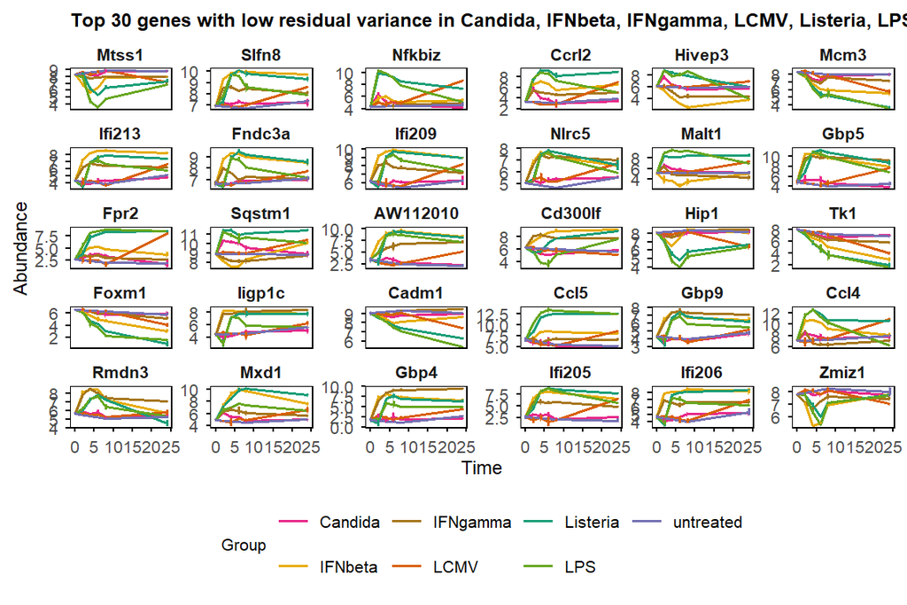

```r
plot_trend(table_mean_sd_orig,
    features = var_decomp_2 %>% arrange(Residual) %>% head(30) %>% pull(Feature),
    title = "Top 30 genes with low residual variance"
)
```

```
#> Group not specified. Plotting all groups: Candida, IFNbeta, IFNgamma, LCMV, Listeria, LPS, untreated
```

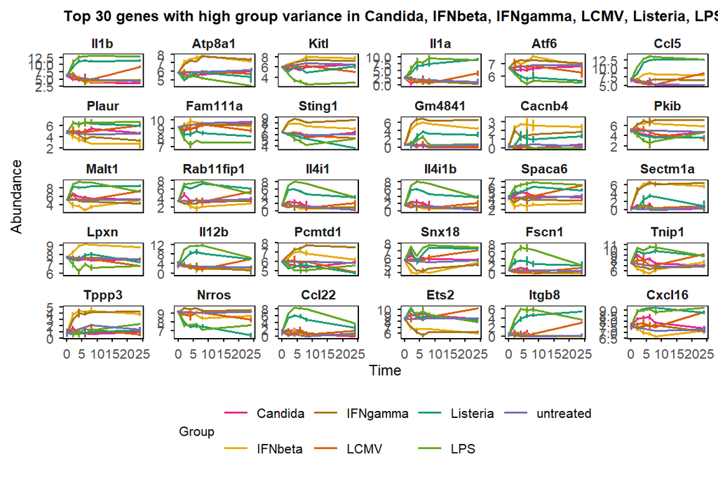

```r
plot_trend(table_mean_sd_orig,
    features = var_decomp_2 %>% arrange(desc(Group)) %>% head(30) %>% pull(Feature),
    title = "Top 30 genes with high group variance"
)
```

```
#> Group not specified. Plotting all groups: Candida, IFNbeta, IFNgamma, LCMV, Listeria, LPS, untreated
```

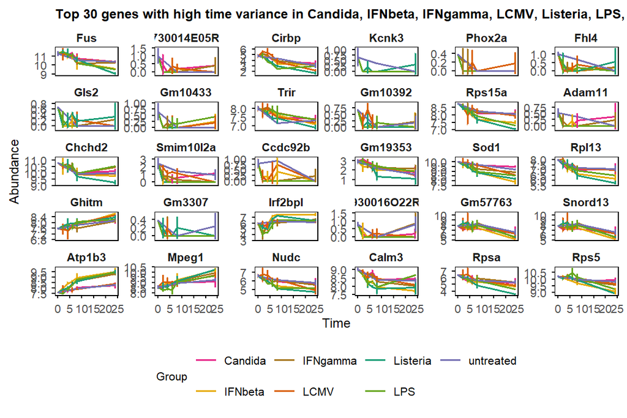

```r
plot_trend(table_mean_sd_orig,
    features = var_decomp_2 %>% arrange(desc(Time)) %>% head(30) %>% pull(Feature),
    title = "Top 30 genes with high time variance"
)
```

```
#> Group not specified. Plotting all groups: Candida, IFNbeta, IFNgamma, LCMV, Listeria, LPS, untreated
```

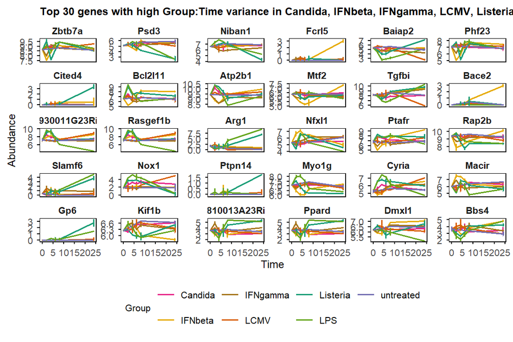

```r
plot_trend(table_mean_sd_orig,
    features = var_decomp_2 %>% arrange(desc(`Group:Time`)) %>% head(30) %>% pull(Feature),
    title = "Top 30 genes with high Group:Time variance"
)
```

## 11.4 Compare variance with / without time 0 normalisation

var_decomp_1: not normalised to time 0

var_decomp_2: normalised to time 0

In this dataset, all groups have the same starting status (untreated), so after normalisation to time 0, the variance decomposition is the same as the original data.

```r
var_decomp_1$Residual %>% summary()
```

```
#>     Min.  1st Qu.   Median     Mean  3rd Qu.     Max.
#>   0.8112  16.5310  34.9845  41.6242  64.6950 100.0000
var_res_q3_1 <- quantile(var_decomp_1$Residual, 0.75)

var_decomp_2$Residual %>% summary()
```

```
#>     Min.  1st Qu.   Median     Mean  3rd Qu.     Max.
#>   0.8112  16.5310  34.9845  41.6242  64.6950 100.0000
var_res_q3_2 <- quantile(var_decomp_2$Residual, 0.75)
```

```r
var_decomp_merged <- merge(var_decomp_1, var_decomp_2,
    by = "Feature",
    suffixes = c(".orig", ".norm")
)

summary(var_decomp_merged$Residual.orig / var_decomp_merged$Residual.norm)
```

```
#>    Min. 1st Qu.  Median    Mean 3rd Qu.    Max.
#>       1       1       1       1       1       1
```

# 12 Module identification with WGCNA

WGCNA reference: https://github.com/edo98811/WGCNA_official_documentation/

## 12.1 Filter input

exclude genes with high residual variance

```r
# time 0 normalised
gene_resid_2 <- var_decomp_2 %>%
    filter(Residual < var_res_q3_2) %>%
    pull(Feature)
length(gene_resid_2) # only including genes with >=50% values >0 in >=2 groups
```

```
#> [1] 10909
```

exclude genes that are random in all groups

```r
non_random_union <- Reduce(union, non_random_list)
length(non_random_union) # all non-random genes have >=50% non NA
```

```
#> [1] 7831
```

```r
group_unique_genes = Reduce(union, group_unique_genes_list)
stopifnot(group_unique_genes %>% unique() %>% length() == length(group_unique_genes))

length(group_unique_genes)
```

```
#> [1] 769
```

use time 0 normalised data with replicates

```r
filter_wgcna <- intersect(gene_resid_2, non_random_union)
    # union(group_unique_genes)
length(filter_wgcna)
```

```
#> [1] 6763

data_obj_filtered <- data_obj[filter_wgcna, ]
dim(data_obj_filtered)
```

```
#> [1] 6763   76
```

## 12.2 Choose power

```r
wgcna_input <- prepare_WGCNA(data_obj_filtered,
    assay = 2,
    blockSize = 20000,
    powers = c(seq(1, 30, by = 1)),
    networkType = "signed",
    RsquaredCut = 0.8,
    MeanConnectivity = 100
)
```

```
#> Allowing multi-threading with up to 24 threads.
#>  pickSoftThreshold: calculating connectivity for given powers...
#>    ..working on genes 1 through 6763 of 6763
#>    Power SFT.R.sq    slope truncated.R.sq mean.k. median.k. max.k.
#> 1      1 7.48e-01  2.82000          0.871  3920.0   4200.00   4690
#> 2      2 2.50e-01  0.66600          0.419  2580.0   2830.00   3700
#> 3      3 4.39e-05  0.00665         -0.202  1830.0   2000.00   3060
#> 4      4 1.19e-01 -0.31700         -0.133  1360.0   1450.00   2600
#> 5      5 3.02e-01 -0.51700          0.152  1050.0   1080.00   2240
#> 6      6 4.28e-01 -0.65200          0.386   821.0    813.00   1950
#> 7      7 5.07e-01 -0.76300          0.529   656.0    618.00   1720
#> 8      8 5.60e-01 -0.85000          0.627   532.0    476.00   1520
#> 9      9 5.89e-01 -0.93600          0.687   437.0    369.00   1350
#> 10    10 6.25e-01 -1.00000          0.741   362.0    288.00   1210
#> 11    11 6.54e-01 -1.06000          0.781   303.0    227.00   1090
```

[output cut: 20 more lines]

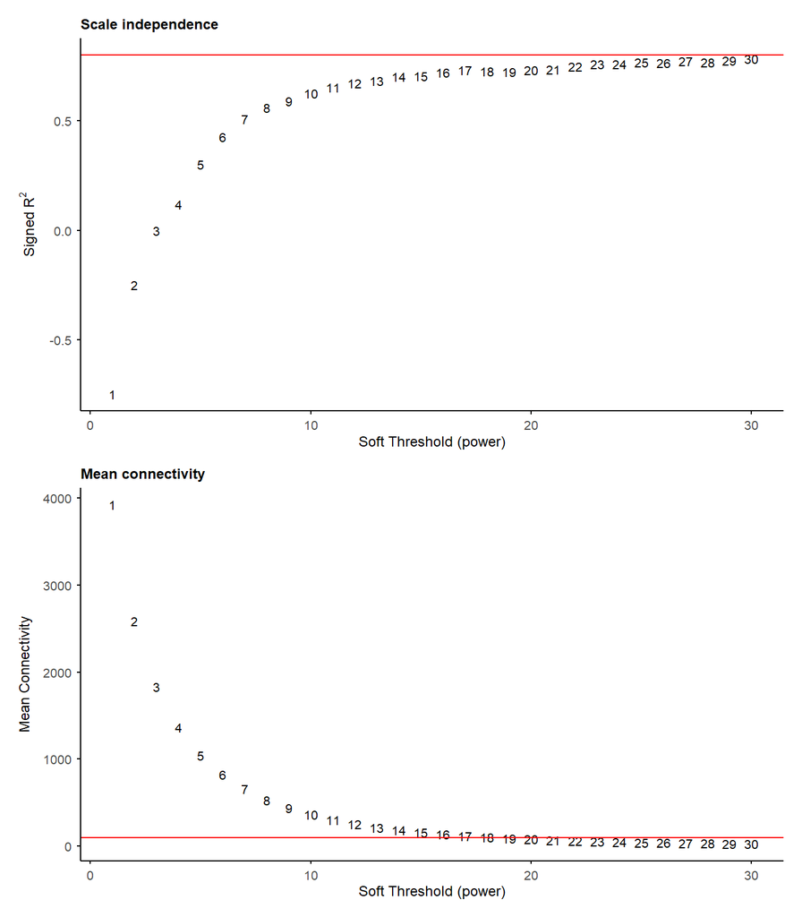

The R2 didn’t reach 0.8 under power 30, so choose the lowest power that reached the plateau.